# CCLCM R/Python Session: Example R Notebook

Here is some R code that is meant to show you what R can do. Programming exists to make our lives easier. R is especially good at this when the task at hand involves exploring, analyzing, and visualizing data.

Sit back and relax as I show you an example of what R can do with a pretend patient dataset, `example_data.csv`

You can find a copy of the data here: https://michelleumd.github.io/CCLCM/example_data.csv

```r
example_data <- read.csv("https://michelleumd.github.io/CCLCM/example_data.csv", na.strings="N/A")
View(example_data)
```

How many patients are in our dataset? How many columns of information do we have for each patient?

```r
print(nrow(example_data))
```

```
## [1] 5110
```

```r
print(ncol(example_data))
```

```
## [1] 37
```

## Everything you can do in Excel, you can do also in R (along with much more)

You may have used functions in Excel to find the mean, median, minimum, and maximum values in a column. In R, this is much easier. With just **one** line of code, we can find all those values and more.

```r
summary(example_data$age_years)
```

```
##    Min. 1st Qu.  Median    Mean 3rd Qu.    Max.
##    0.08   25.00   45.00   43.23   61.00   82.00
```

Now let’s do that for every column in our dataset.

```r
sapply(example_data, summary, na.rm=TRUE)
```

```
## $id
##    Min. 1st Qu.  Median    Mean 3rd Qu.    Max.
##      67   17741   36932   36518   54682   72940
##
## $sex
##    Length     Class      Mode
##      5110 character character
##
## $age_years
##    Min. 1st Qu.  Median    Mean 3rd Qu.    Max.
##    0.08   25.00   45.00   43.23   61.00   82.00
##
## $age_days
##    Min. 1st Qu.  Median    Mean 3rd Qu.    Max.
##      29    9125   16425   15778   22265   29930
##
## $hypertension
##    Min. 1st Qu.  Median    Mean 3rd Qu.    Max.
## 0.00000 0.00000 0.00000 0.09746 0.00000 1.00000
##
## $heart_disease
##    Min. 1st Qu.  Median    Mean 3rd Qu.    Max.
## 0.00000 0.00000 0.00000 0.05401 0.00000 1.00000
##
## $ever_married
##    Length     Class      Mode
##      5110 character character
##
## $work_type
##    Length     Class      Mode
##      5110 character character
##
## $Residence_type
##    Length     Class      Mode
##      5110 character character
##
## $avg_glucose_level
##    Min. 1st Qu.  Median    Mean 3rd Qu.    Max.
##   55.12   77.25   91.89  106.15  114.09  271.74
##
```

[output cut: 92 more lines]

```
## $serum_creatinine
##    Min. 1st Qu.  Median    Mean 3rd Qu.    Max.
##   0.500   0.900   1.100   1.396   1.400   9.400
##
## $serum_sodium
##    Min. 1st Qu.  Median    Mean 3rd Qu.    Max.
##   113.0   134.0   137.0   136.6   140.0   148.0
##
## $time
##    Min. 1st Qu.  Median    Mean 3rd Qu.    Max.
##     4.0    72.0   113.0   129.6   201.0   285.0
##
## $DEATH_EVENT
##    Min. 1st Qu.  Median    Mean 3rd Qu.    Max.
##  0.0000  0.0000  0.0000  0.3241  1.0000  1.0000
```

You may have used Excel to create figures. R is a great software for producing publication-level figures. With just **two** lines of code, we can produce a histogram!

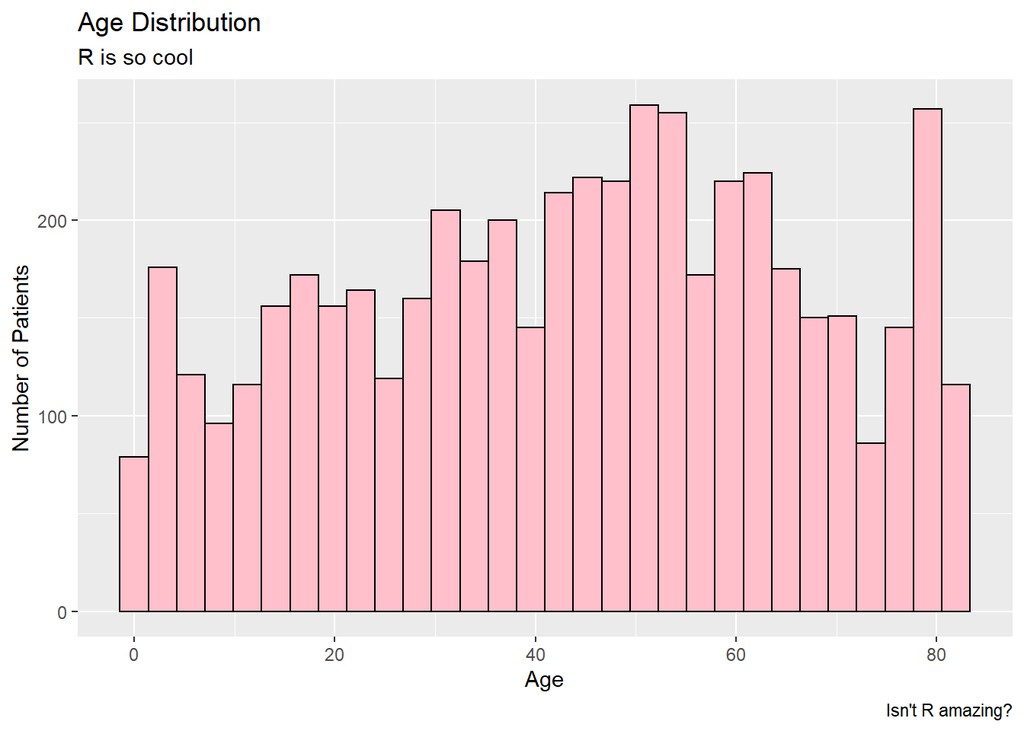

```r
library(ggplot2)
ggplot(example_data, aes(x=age_years)) + geom_histogram(color="black", fill="pink") + labs(title="Age Distribution", subtitle="R is so cool", y="Number of Patients",  x="Age", caption="Isn't R amazing?")
```

## Statistical Modeling and Testing

The ultimate reason why people use R is becuase it is so powerful when it comes to statistical testing

With just **one** line of code, I can do a two-sample Mann-Whitney-Wilcoxon Test and get a p-value to see if there is a statistically significant difference between average glucose level between sexes.

```r
wilcox.test(avg_glucose_level ~ sex, data=example_data)
```

```
##
##  Wilcoxon rank sum test with continuity correction
##
## data:  avg_glucose_level by sex
## W = 2986625, p-value = 0.0005076
## alternative hypothesis: true location shift is not equal to 0
```

There are so many other tests that are just as easy to do in R. To name a few:

- Student’s t-test
- Chi-square test
- ANOVA test
- Kruskal Wallis test
- Pearson correlation test
- Multiple testing correction

You can basically do any statistical test that exists in R. If a new statistical method is invented, chances are code will become available in R for it very soon after.

You can also use R for regression. Here’s an example of linear regression

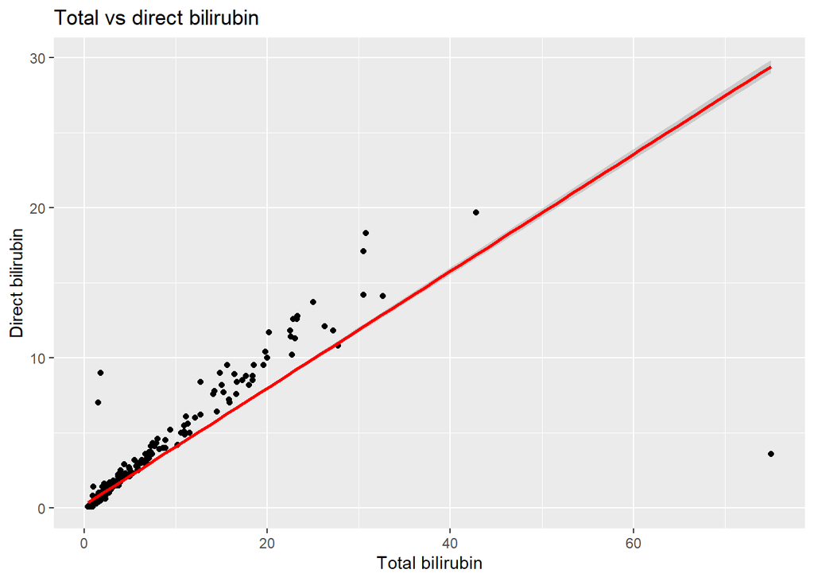

```r
ggplot(example_data, aes(x = tot_bilirubin, y = direct_bilirubin)) + geom_point(col = "black") + geom_smooth(method="lm", col = "red") + labs(title="Total vs direct bilirubin", y="Direct bilirubin",  x="Total bilirubin")
```

```r
lm(example_data$direct_bilirubin ~ example_data$tot_bilirubin)
```

```
##
## Call:
## lm(formula = example_data$direct_bilirubin ~ example_data$tot_bilirubin)
##
## Coefficients:
##                (Intercept)  example_data$tot_bilirubin
##                     0.1920                      0.3897
```

Adding just a bit more code, we can get more information on the statistical significance of the line

```r
summary(lm(example_data$direct_bilirubin ~ example_data$tot_bilirubin)
)
```

```
##
## Call:
## lm(formula = example_data$direct_bilirubin ~ example_data$tot_bilirubin)
##
## Residuals:
##      Min       1Q   Median       3Q      Max
## -25.8222  -0.3038  -0.2648   0.0167   8.1065
##
## Coefficients:
##                            Estimate Std. Error t value Pr(>|t|)
## (Intercept)                0.192003   0.021613   8.884   <2e-16 ***
## example_data$tot_bilirubin 0.389736   0.003116 125.092   <2e-16 ***
## ---
## Signif. codes:  0 '***' 0.001 '**' 0.01 '*' 0.05 '.' 0.1 ' ' 1
##
## Residual standard error: 1.366 on 5108 degrees of freedom
## Multiple R-squared:  0.7539, Adjusted R-squared:  0.7539
## F-statistic: 1.565e+04 on 1 and 5108 DF,  p-value: < 2.2e-16
```

There are so many types of regression that R can do. Just to name a few:

- Exponential Regression
- Logistic Regression
- Kaplan-Meyer
- Cox Proportional Hazards

## Even cooler stuff

with just **two** lines of code, we can generate an entire report that sums up every column in our dataset. This is a great first step in any data exploration.

I have included the result at https://michelleumd.github.io/CCLCM/report.html

```r
library(DataExplorer, quietly = TRUE, warn.conflicts = FALSE)
create_report(example_data)
```

```
##
##
## processing file: report.rmd
```

[output not shown]

[output not shown]

[output not shown]

[output not shown]

[output not shown]

[output not shown]

[output not shown]

[output not shown]

```
## output file: C:/Users/miche/Desktop/report.knit.md
```

[output not shown]

```
##
## Output created: report.html
```

In studies that involve human subjects, “Table 1” is commonly reserved to show baseline characteristics of the study population. Did you know this table can be made with just a few lines of code?

```r
library(tableone)
table1 <- CreateTableOne(vars = c("sex", "age_years","heart_disease", "ldl", "hdl", "diabetes", "bmi", "DEATH_EVENT"),
                         data=example_data,
                         factorVars = c("sex", "heart_disease", "diabetes", "DEATH_EVENT"),
                         includeNA=F)

print(table1,  noSpaces = TRUE, showAllLevels = TRUE)
```

```
##
##                         level  Overall
##   n                            5110
##   sex (%)               Female 2995 (58.6)
##                         Male   2115 (41.4)
##   age_years (mean (SD))        43.23 (22.61)
##   heart_disease (%)     0      4834 (94.6)
##                         1      276 (5.4)
##   ldl (mean (SD))              125.46 (43.57)
##   hdl (mean (SD))              60.70 (23.22)
##   diabetes (%)          0      2978 (58.3)
##                         1      2132 (41.7)
##   bmi (mean (SD))              28.89 (7.85)
##   DEATH_EVENT (%)       0      3454 (67.6)
##                         1      1656 (32.4)
```

We can print random, fun cat facts

```r
library("cowsay", quietly = TRUE, warn.conflicts = FALSE)
say("catfact", "cat")
```

```
##
##  --------------
## The normal body temperature of a cat is between 100.5 ° and 102.5 °F. A cat is sick if its temperature goes below 100 ° or above 103 °F.
##  --------------
##     \
##       \
##         \
##             |\___/|
##           ==) ^Y^ (==
##             \  ^  /
##              )=*=(
##             /     \
##             |     |
##            /| | | |\
##            \| | |_|/\
##       jgs  //_// ___/
##                \_)
##
```

Other things you can do (omitted here)

- Create interative figures
- Play sounds/make music
- Post tweets to Twitter
- Many more things